# Course Project - Practical Machine Learning

Vergara, Enrico Marco

June 17, 2019

## ————————————————————————————————

### I. Overview

#### A. Background

Using devices such as Jawbone Up, Nike FuelBand, and Fitbit it is now possible to collect a large amount of data about personal activity relatively inexpensively. These type of devices are part of the quantified self movement â a group of enthusiasts who take measurements about themselves regularly to improve their health, to find patterns in their behavior, or because they are tech geeks. One thing that people regularly do is quantify how much of a particular activity they do, but they rarely quantify how well they do it. In this project, your goal will be to use data from accelerometers on the belt, forearm, arm, and dumbell of 6 participants. They were asked to perform barbell lifts correctly and incorrectly in 5 different ways.

#### B. Data Definition

The data for this project come from this source: http://groupware.les.inf.puc-rio.br/har

**Title:** Weight Lifting Exercises Dataset

**Basic Summary:** This human activity recognition research has traditionally focused on discriminating between different activities, i.e. to predict “which” activity was performed at a specific point in time. The approach we propose for the Weight Lifting Exercises dataset is to investigate “how (well)” an activity was performed by the wearer. The “how (well)” investigation has only received little attention so far, even though it potentially provides useful information for a large variety of applications,such as sports training.

Six young health participants were asked to perform one set of 10 repetitions of the Unilateral Dumbbell Biceps Curl in five different fashions: exactly according to the specification (Class A), throwing the elbows to the front (Class B), lifting the dumbbell only halfway (Class C), lowering the dumbbell only halfway (Class D) and throwing the hips to the front (Class E).

**Source:** *Velloso, E.; Bulling, A.; Gellersen, H.; Ugulino, W.; Fuks, H. Qualitative Activity Recognition of Weight Lifting Exercises. Proceedings of 4th International Conference in Cooperation with SIGCHI (Augmented Human ’13) . Stuttgart, Germany: ACM SIGCHI, 2013.*

## ————————————————————————————————

### II. Data Pre-processing and Correlation Analysis

#### A. Data Loading

In this section, the initial processing of data is provided. The first thing to do is to download and load the data frame by storing it into a variable.

```r
url_train <- "http://d396qusza40orc.cloudfront.net/predmachlearn/pml-training.csv"
url_test  <- "http://d396qusza40orc.cloudfront.net/predmachlearn/pml-testing.csv"
pml_train <- read.csv(url(url_train))
pml_validation  <- read.csv(url(url_test))
```

#### B. Data Partitioning

For the prediction model, the training data is to be splitted into the “ideal” ratio of data partition for training and testing which is 70% as train data and 30% test data. This splitted data will also be used for the computation of the out-of-sample errors.

```r
set.seed(123456789)
partition  <- createDataPartition(pml_train$classe, p=0.7, list=FALSE)
train_set <- pml_train[partition, ]
test_set  <- pml_train[-partition, ]

dim(train_set)
```

```
## [1] 13737   160
```

```r
dim(test_set)
```

```
## [1] 5885  160
```

The training data set is made of **13737 observations** on **160 variables**. On the other hand, the testing data set is composed of **5885 observations** on **160 variables**.

```r
str(train_set)
```

```
## 'data.frame':    13737 obs. of  160 variables:
##  $ X                       : int  3 4 6 7 8 9 10 11 12 13 ...
##  $ user_name               : Factor w/ 6 levels "adelmo","carlitos",..: 2 2 2 2 2 2 2 2 2 2 ...
##  $ raw_timestamp_part_1    : int  1323084231 1323084232 1323084232 1323084232 1323084232 1323084232 1323084232 1323084232 1323084232 1323084232 ...
##  $ raw_timestamp_part_2    : int  820366 120339 304277 368296 440390 484323 484434 500302 528316 560359 ...
##  $ cvtd_timestamp          : Factor w/ 20 levels "02/12/2011 13:32",..: 9 9 9 9 9 9 9 9 9 9 ...
##  $ new_window              : Factor w/ 2 levels "no","yes": 1 1 1 1 1 1 1 1 1 1 ...
##  $ num_window              : int  11 12 12 12 12 12 12 12 12 12 ...
##  $ roll_belt               : num  1.42 1.48 1.45 1.42 1.42 1.43 1.45 1.45 1.43 1.42 ...
##  $ pitch_belt              : num  8.07 8.05 8.06 8.09 8.13 8.16 8.17 8.18 8.18 8.2 ...
##  $ yaw_belt                : num  -94.4 -94.4 -94.4 -94.4 -94.4 -94.4 -94.4 -94.4 -94.4 -94.4 ...
##  $ total_accel_belt        : int  3 3 3 3 3 3 3 3 3 3 ...
##  $ kurtosis_roll_belt      : Factor w/ 397 levels "","-0.016850",..: 1 1 1 1 1 1 1 1 1 1 ...
##  $ kurtosis_picth_belt     : Factor w/ 317 levels "","-0.021887",..: 1 1 1 1 1 1 1 1 1 1 ...
##  $ kurtosis_yaw_belt       : Factor w/ 2 levels "","#DIV/0!": 1 1 1 1 1 1 1 1 1 1 ...
```

[output cut: 86 more lines]

From the summary, it is noticeable that many columns have NA values or blank values on almost every observation. This is an indication of irrelevant featuresm thus it is safe to consider removing them. The behavior is pretty much similar for both testing and training set. Thus what will be applied to training in terms of cleaning will be also applied to testing.

#### C. Data Cleaning

##### a. Definitive Variables

The first seven columns give information about the people who did the test, and also timestamps. This are again irrelevant for the model. So the first thing to consider is removing this variables.

```r
train_set_clean <- train_set[,-c(1:7)]
test_set_clean <- test_set[,-c(1:7)]
```

##### b. Near Zero Covariates

It is highly emphasized that if there are near zero variables in the data. It is just proper to removed them since it only makes the model bias and inaccurate.

```r
nzv <- nearZeroVar(train_set_clean,saveMetrics=TRUE)
train_set_clean <- train_set_clean[, nzv$nzv==FALSE]
test_set_clean <- test_set_clean[, nzv$nzv==FALSE]
nzv
```

```
##                            freqRatio percentUnique zeroVar   nzv
## roll_belt                   1.034375    8.08764650   FALSE FALSE
## pitch_belt                  1.204918   12.17150761   FALSE FALSE
## yaw_belt                    1.077348   13.15425493   FALSE FALSE
## total_accel_belt            1.077358    0.21110868   FALSE FALSE
## kurtosis_roll_belt       1681.000000    2.05284997   FALSE  TRUE
## kurtosis_picth_belt       707.789474    1.71798792   FALSE  TRUE
## kurtosis_yaw_belt          46.532872    0.01455922   FALSE  TRUE
## skewness_roll_belt       1921.142857    2.05284997   FALSE  TRUE
## skewness_roll_belt.1      707.789474    1.81262284   FALSE  TRUE
## skewness_yaw_belt          46.532872    0.01455922   FALSE  TRUE
## max_roll_belt               1.142857    1.15745796   FALSE FALSE
## max_picth_belt              1.625000    0.15287181   FALSE FALSE
## max_yaw_belt              517.230769    0.40765815   FALSE  TRUE
## min_roll_belt               1.125000    1.12105991   FALSE FALSE
## min_pitch_belt              2.157895    0.10919415   FALSE FALSE
## min_yaw_belt              517.230769    0.40765815   FALSE  TRUE
## amplitude_roll_belt         1.304348    0.85899396   FALSE FALSE
## amplitude_pitch_belt        3.276596    0.09463493   FALSE FALSE
## amplitude_yaw_belt         49.260073    0.02911844   FALSE  TRUE
## var_total_accel_belt        1.482143    0.40765815   FALSE FALSE
## avg_roll_belt               1.090909    1.13561913   FALSE FALSE
## stddev_roll_belt            1.000000    0.45861542   FALSE FALSE
## var_roll_belt               1.648148    0.56780957   FALSE FALSE
## avg_pitch_belt              1.000000    1.26665211   FALSE FALSE
## stddev_pitch_belt           1.086957    0.28390478   FALSE FALSE
## var_pitch_belt              1.159420    0.40765815   FALSE FALSE
## avg_yaw_belt                1.125000    1.37584625   FALSE FALSE
## stddev_yaw_belt             1.875000    0.37126010   FALSE FALSE
## var_yaw_belt                1.354839    0.87355318   FALSE FALSE
## gyros_belt_x                1.072034    0.92451045   FALSE FALSE
## gyros_belt_y                1.153819    0.46589503   FALSE FALSE
## gyros_belt_z                1.064205    1.20113562   FALSE FALSE
## accel_belt_x                1.068519    1.17201718   FALSE FALSE
## accel_belt_y                1.122109    0.99730654   FALSE FALSE
## accel_belt_z                1.055921    2.11836646   FALSE FALSE
## magnet_belt_x               1.108871    2.21300138   FALSE FALSE
## magnet_belt_y               1.103604    2.08196841   FALSE FALSE
## magnet_belt_z               1.002924    3.15207105   FALSE FALSE
## roll_arm                   47.560000   17.36186940   FALSE FALSE
```

[output cut: 99 more lines]

```
## stddev_pitch_forearm       65.000000    1.63791221   FALSE  TRUE
## var_pitch_forearm          65.000000    1.63791221   FALSE  TRUE
## avg_yaw_forearm            65.000000    1.63791221   FALSE  TRUE
## stddev_yaw_forearm         67.000000    1.62335299   FALSE  TRUE
## var_yaw_forearm            67.000000    1.62335299   FALSE  TRUE
## gyros_forearm_x             1.074792    2.06012958   FALSE FALSE
## gyros_forearm_y             1.029412    5.24859868   FALSE FALSE
## gyros_forearm_z             1.137313    2.14020528   FALSE FALSE
## accel_forearm_x             1.047619    5.67809565   FALSE FALSE
## accel_forearm_y             1.000000    7.11217879   FALSE FALSE
## accel_forearm_z             1.185185    4.04746306   FALSE FALSE
## magnet_forearm_x            1.000000   10.61367111   FALSE FALSE
## magnet_forearm_y            1.163934   13.37264323   FALSE FALSE
## magnet_forearm_z            1.000000   11.84392517   FALSE FALSE
## classe                      1.469526    0.03639805   FALSE FALSE
```

##### c. NA Values

From the summary, it is very evident that most of the variables are composed on NA values. If large portion of the covariate is just NA values. It is might as well good to consider removing this covariates.

```r
allNA <- sapply(train_set_clean, function(x) mean(is.na(x))) > 0.95
train_set_clean <- train_set_clean[, allNA==FALSE]
test_set_clean <- test_set_clean[, allNA==FALSE]
```

#### D. Correlation Analysis

Lastly, correlation analysis is applied to the partly cleaned data. The goal is to eliminate highly correlated covariates because from the lesson, it is highly emphasized that highly correlated variables don’t improve models for the reason that it mask interactions between different features.

In order to visualize the correlation of each covariates, here is the correlation plot.

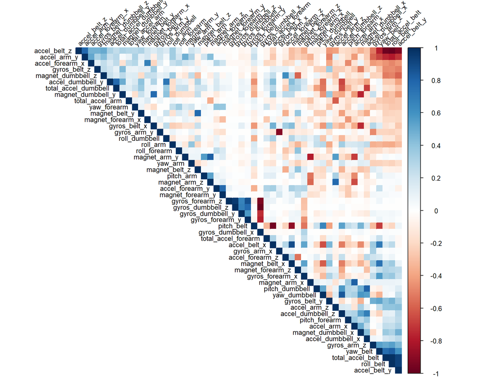

```r
corrplot(cor(train_set_clean[, -53]), order = "FPC", method = "color", type = "upper", tl.cex = 0.8, tl.col = rgb(0, 0, 0), tl.srt=45)
```

As can be noticed, some of the covariates are highly correlated. For this purpose, highly correlated covariates are defined to have a cut off of at least 0.90 in absolute value. Identified variables will then be excluded from the predictors.

```r
c <- findCorrelation(abs(cor(train_set_clean[, -53])), cutoff = .90)
train_set_clean <- train_set_clean[, -c]
test_set_clean <- test_set_clean[, -c]
dim(train_set_clean)
```

```
## [1] 13737    46
```

```r
dim(test_set_clean)
```

```
## [1] 5885   46
```

There are a total of seven highly correlated variables based on the threshold. After all the cleaning process applied to the original partitioned data set, the number of covariates for the modeling has been reduced from **159 predictors** to only **45 predictors** plus **one outcome variable**.

## ————————————————————————————————

### III. Prediction Model Building

For this project, there will be three algorithm to be used in order to discover the best model to predict the class or fashion of performing the Unilateral Dumbbell Biceps Curl based on the given variables. The three algorithms are:

1. Decision Tree
2. Random Forests
3. Gradient Boosting Method

#### A. Decision Tree Algorithm

A Decision Tree is a supervised learning predictive model that uses a set of binary rules to calculate a target value.  
Source: *[A Guide to Machine Learning in R for Beginners: Decision Trees](https://medium.com/analytics-vidhya/a-guide-to-machine-learning-in-r-for-beginners-decision-trees-c24dfd490abb)*

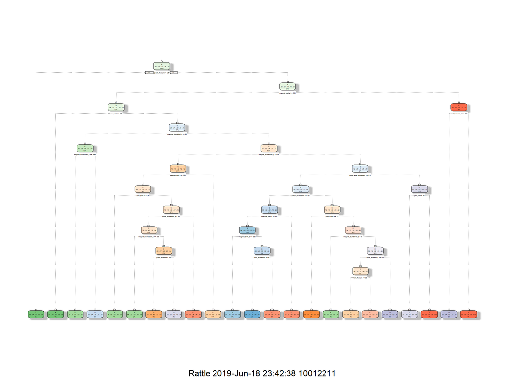

```r
set.seed(123456789)
model_decisiontree <- rpart(classe ~ ., data=train_set_clean, method="class")
fancyRpartPlot(model_decisiontree)
```

```r
prediction_model_decisiontree <- predict(model_decisiontree, newdata=test_set_clean, type="class")
cm_model_decisiontree <- confusionMatrix(prediction_model_decisiontree, test_set_clean$classe)
cm_model_decisiontree
```

```
## Confusion Matrix and Statistics
##
##           Reference
## Prediction    A    B    C    D    E
##          A 1387  184   19   28  133
##          B   18  546   46   90   49
##          C   79  191  853  155   71
##          D  178  138   59  643   98
##          E   12   80   49   48  731
##
## Overall Statistics
##
##                Accuracy : 0.7069
##                  95% CI : (0.6951, 0.7185)
##     No Information Rate : 0.2845
##     P-Value [Acc > NIR] : < 2.2e-16
##
##                   Kappa : 0.6294
##
##  Mcnemar's Test P-Value : < 2.2e-16
##
## Statistics by Class:
##
##                      Class: A Class: B Class: C Class: D Class: E
## Sensitivity            0.8286  0.47937   0.8314   0.6670   0.6756
## Specificity            0.9136  0.95723   0.8979   0.9039   0.9606
## Pos Pred Value         0.7921  0.72897   0.6323   0.5762   0.7946
## Neg Pred Value         0.9306  0.88454   0.9619   0.9327   0.9293
## Prevalence             0.2845  0.19354   0.1743   0.1638   0.1839
## Detection Rate         0.2357  0.09278   0.1449   0.1093   0.1242
## Detection Prevalence   0.2975  0.12727   0.2292   0.1896   0.1563
## Balanced Accuracy      0.8711  0.71830   0.8647   0.7854   0.8181
```

#### B. Random Forest Algorithm

In Random Forests the idea is to decorrelate the several trees which are generated by the different bootstrapped samples from training Data. And then we simply reduce the Variance in the Trees by averaging them.  
Source: *[Random Forests in R](https://datascienceplus.com/random-forests-in-r/)*

```r
set.seed(123456789)
traincontrol_ranfor <- trainControl(method="cv", number=3, verboseIter=FALSE)
model_randomforest <- train(classe ~ ., data=train_set_clean, method="rf", trControl=traincontrol_ranfor)
model_randomforest
```

```
## Random Forest
##
## 13737 samples
##    45 predictor
##     5 classes: 'A', 'B', 'C', 'D', 'E'
##
## No pre-processing
## Resampling: Cross-Validated (3 fold)
## Summary of sample sizes: 9160, 9157, 9157
## Resampling results across tuning parameters:
##
##   mtry  Accuracy   Kappa
##    2    0.9871156  0.9837005
##   23    0.9886443  0.9856364
##   45    0.9830392  0.9785436
##
## Accuracy was used to select the optimal model using the largest value.
## The final value used for the model was mtry = 23.
```

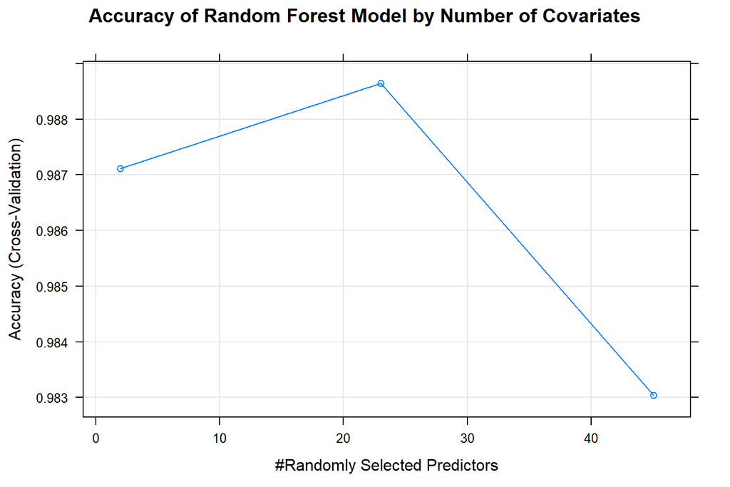

```r
plot(model_randomforest,main="Accuracy of Random Forest Model by Number of Covariates")
```

```r
prediction_model_ranfor <- predict(model_randomforest, newdata=test_set_clean)
cm_model_ranfor<- confusionMatrix(prediction_model_ranfor, test_set_clean$classe)
cm_model_ranfor
```

```
## Confusion Matrix and Statistics
##
##           Reference
## Prediction    A    B    C    D    E
##          A 1673   10    0    0    0
##          B    1 1128   13    0    0
##          C    0    1 1010   15    2
##          D    0    0    3  948    1
##          E    0    0    0    1 1079
##
## Overall Statistics
##
##                Accuracy : 0.992
##                  95% CI : (0.9894, 0.9941)
##     No Information Rate : 0.2845
##     P-Value [Acc > NIR] : < 2.2e-16
##
##                   Kappa : 0.9899
##
##  Mcnemar's Test P-Value : NA
##
## Statistics by Class:
##
##                      Class: A Class: B Class: C Class: D Class: E
## Sensitivity            0.9994   0.9903   0.9844   0.9834   0.9972
## Specificity            0.9976   0.9971   0.9963   0.9992   0.9998
## Pos Pred Value         0.9941   0.9877   0.9825   0.9958   0.9991
## Neg Pred Value         0.9998   0.9977   0.9967   0.9968   0.9994
## Prevalence             0.2845   0.1935   0.1743   0.1638   0.1839
## Detection Rate         0.2843   0.1917   0.1716   0.1611   0.1833
## Detection Prevalence   0.2860   0.1941   0.1747   0.1618   0.1835
## Balanced Accuracy      0.9985   0.9937   0.9904   0.9913   0.9985
```

#### C. Gradient Boosting Method

The main idea of boosting is to add new models to the ensemble sequentially. At each particular iteration, a new weak, base-learner model is trained with respect to the error of the whole ensemble learnt so far.  
Source: *[Gradient Boosting Machines](http://uc-r.github.io/gbm_regression)*

```r
set.seed(123456789)
traincontrol_gbm <- trainControl(method = "repeatedcv", number = 5, repeats = 1)
model_gbm  <- train(classe ~ ., data=train_set_clean, method = "gbm", trControl = traincontrol_gbm, verbose = FALSE)
model_gbm
```

```
## Stochastic Gradient Boosting
##
## 13737 samples
##    45 predictor
##     5 classes: 'A', 'B', 'C', 'D', 'E'
##
## No pre-processing
## Resampling: Cross-Validated (5 fold, repeated 1 times)
## Summary of sample sizes: 10989, 10988, 10990, 10990, 10991
## Resampling results across tuning parameters:
##
##   interaction.depth  n.trees  Accuracy   Kappa
##   1                   50      0.7417204  0.6728296
##   1                  100      0.8083285  0.7574831
##   1                  150      0.8415238  0.7994574
##   2                   50      0.8480031  0.8074418
##   2                  100      0.9027450  0.8769248
##   2                  150      0.9269861  0.9075945
##   3                   50      0.8905879  0.8614977
##   3                  100      0.9370308  0.9203304
##   3                  150      0.9558125  0.9440984
##
## Tuning parameter 'shrinkage' was held constant at a value of 0.1
##
## Tuning parameter 'n.minobsinnode' was held constant at a value of 10
## Accuracy was used to select the optimal model using the largest value.
## The final values used for the model were n.trees = 150,
##  interaction.depth = 3, shrinkage = 0.1 and n.minobsinnode = 10.
```

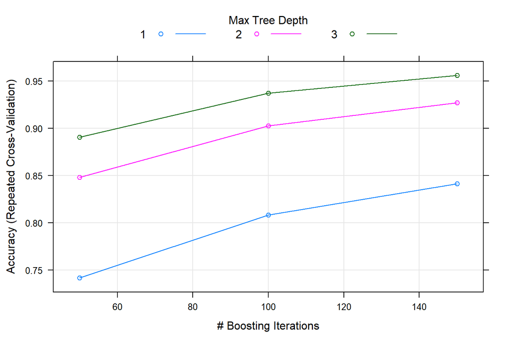

```r
plot(model_gbm)
```

```r
prediction_model_gbm <- predict(model_gbm, newdata=test_set_clean)
cm_model_gbm <- confusionMatrix(prediction_model_gbm, test_set_clean$classe)
cm_model_gbm
```

```
## Confusion Matrix and Statistics
##
##           Reference
## Prediction    A    B    C    D    E
##          A 1644   46    0    1    5
##          B   18 1052   31    7   10
##          C    9   36  979   35   13
##          D    2    2   16  915    6
##          E    1    3    0    6 1048
##
## Overall Statistics
##
##                Accuracy : 0.958
##                  95% CI : (0.9526, 0.963)
##     No Information Rate : 0.2845
##     P-Value [Acc > NIR] : < 2.2e-16
##
##                   Kappa : 0.9469
##
##  Mcnemar's Test P-Value : 1.571e-07
##
## Statistics by Class:
##
##                      Class: A Class: B Class: C Class: D Class: E
## Sensitivity            0.9821   0.9236   0.9542   0.9492   0.9686
## Specificity            0.9877   0.9861   0.9809   0.9947   0.9979
## Pos Pred Value         0.9693   0.9410   0.9132   0.9724   0.9905
## Neg Pred Value         0.9928   0.9817   0.9902   0.9901   0.9930
## Prevalence             0.2845   0.1935   0.1743   0.1638   0.1839
## Detection Rate         0.2794   0.1788   0.1664   0.1555   0.1781
## Detection Prevalence   0.2882   0.1900   0.1822   0.1599   0.1798
## Balanced Accuracy      0.9849   0.9549   0.9675   0.9719   0.9832
```

## ————————————————————————————————

### IV. Result Summary and Conclusion

Presented below is the table to summarize the output characteristics of the model created using the different algorithms.

[output not shown]

From the result above, it is clear that **Random Forest Algorithm** provided the best predictive model for the class or fashion of performing the Unilateral Dumbbell Biceps Curl based on the given variables.

## ————————————————————————————————

### V. Application

This section shows the application of the selected best predictive model (using Random Forest Algorithm) to the given set of testing data for the evaluation exercises.

```r
evaluation_prediction <- predict(model_randomforest, newdata=pml_validation)
evaluation_prediction
```

```
##  [1] B A B A A E D B A A B C B A E E A B B B
## Levels: A B C D E
```